# Donut Chart and Geofacets with Images

In this post, I recreate the donut chart overlaid on geo facets. Based on a friend’s feedback, I now add pictures of winners of each state.

Ashwin Malshe www.ashwinmalshe.com  
2020-12-02

For the background and more details on this plot, please check out my earlier blog post: https://dataviz.school/posts/2020-11-20--us-election-donut/

## Getting the data

As of the date of this writing (21st November 2020), the results of the US Presidential elections have not tallied. The counting is still going on in a few states. However, it is unlikely that the results will change significantly from this point onward. I decided to get data from this Github repo, which scrapes data from NYT. The data is at county-level: https://github.com/favstats/USElection2020-NYT-Results

## Final plot

[Trump icon](https://icons8.com/icons/set/donald-trump) [Biden icon](https://icons8.com/icons/set/joe-biden)

These are free to use with attribution.

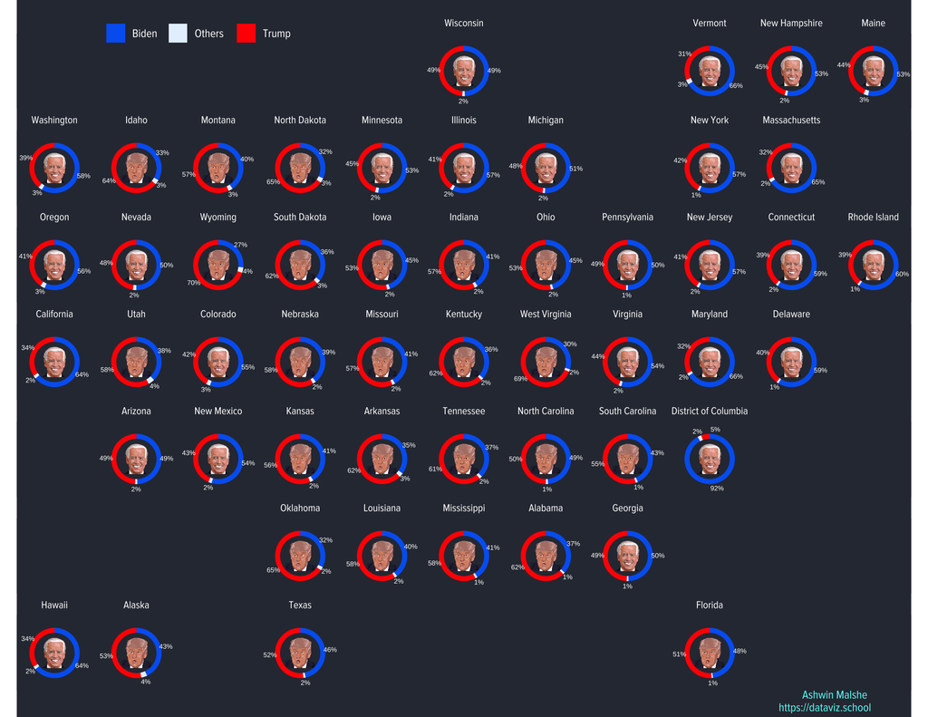

## Code to create the plot

Here is the code to recreate these plots. Note that I am assuming that you are using the code to prepare data from my [previous post](https://dataviz.school/posts/2020-11-20--us-election-donut/).

The main challenge in creating this plot is mismatch of the coordinate system. The donuts are created using polar coordinates. It’s not possible to overlay images on top of those donuts in `ggplot2`. I decided to use a workaround, which I have successfully used in the past to create dataviz for my wife. I first created two separate plots. First plot is the main donut chart which I created previously. The second plot is just a facet plot of Biden and Trump images. Next I used `cowplot` package to overlay these two plots on top of each other. It may sound pretty easy but it took me a lot of time to align those two plots perfectly. The key was to use `coord_fixed()` in the second plot.

### Create a data set with images

```
dt3 <- dt2 %>%
  arrange(state, -votes) %>%
  group_by(state) %>%
  filter(row_number() == 1) %>%
  ungroup() %>%
  mutate(image = case_when(Candidate == "Biden" ~ "https://github.com/ashgreat/dataviz-blog/raw/main/Images/joe-biden.png",
                           Candidate == "Trump" ~ "https://github.com/ashgreat/dataviz-blog/raw/main/Images/donald-trump.png"),
         image2 = case_when(Candidate == "Biden" ~ "https://github.com/ashgreat/dataviz-blog/raw/main/Images/biden-small-pixabay.png",
                           Candidate == "Trump" ~ "https://github.com/ashgreat/dataviz-blog/raw/main/Images/trump-small-pixabay.png")
         )
```

### Create donut charts

This code is basically copied from the previous post.

```
g3 <- dt2 %>%
  group_by(state) %>%
  arrange(Candidate) %>%
  mutate(ymax = cumsum(per_votes),
         ymin = ifelse(row_number() == 1, 0, lag(ymax)),
         ypos = (ymin + ymax) / 2) %>%
  ungroup() %>%
  ggplot(aes(ymin = ymin, ymax = ymax, xmin = 3, xmax = 4)) +
  geom_rect(aes(fill = Candidate)) +
  geom_text(x = 5,
             aes(y = ypos,
                 label = formattable::percent(round(per_votes, 2), digits = 0)),
             size = 2, color = "white") +
  coord_polar(theta = "y") +
  facet_geo(~state) +
  scale_fill_manual(values = c("#0066f2", "#e6f1fd", "#ff0000")) +
  theme_void()+
  xlim(-1, 5) +
  labs(caption = "Ashwin Malshe \nhttps://dataviz.school",
       subtitle = " ") +
  theme(legend.text = element_text(family = "proxima", size = 10, color = "white"),
        legend.title = element_blank(),
        legend.direction = "horizontal",
        legend.position = c(0.2, 1),
        plot.caption = element_text(family = "proxima", size = 10, hjust = 0.95,
                                    margin = margin(0, 0, 5, 0, "pt"),
                                    face = "bold", color = "#69fffb"),
        strip.text = element_text(family = "proxima", size = 9, color = "white",
                                  margin = margin(0, 0, 5, 0, "pt")),
        strip.background = element_blank(),
        plot.background = element_rect(fill = "#2e3440", color = NA),
        panel.background = element_rect(fill = "#2e3440", color = NA))


# Print the plot

g3
```

### Create the plot of images

This is the plot that will be layered on top of the donut chart. Note `geon_image()` from `ggimage` package.

```
g4 <- ggplot(dt3) +
  facet_geo(~state) +
  ggimage::geom_image(aes(x = 0.5, y = -1, image = image), size = 0.5) +
  theme_void()+
  xlim(0, 1) +
  coord_fixed() + # This is critical!
  theme(
        strip.background = element_blank(),
        strip.text = element_blank(),
        panel.background = element_blank(),
        plot.background = element_blank())
```

### Superimposing the two plots

This was easy. I just layered `g4` on `g3` using `align_plots()` from the fatnastic package `cowplot`. Finally, I plotted them and saved in an object `g5`. Note that if you use the same font as the one I used here, `cowplot` will generate many error messages. Ignore them as it won’t affect your output.

```
aligned_plots <- cowplot::align_plots(g3, g4, align="hv", greedy = FALSE)

g5 <- ggdraw(aligned_plots[[1]]) +
  draw_plot(aligned_plots[[2]])
```

I hope you enjoyed this post!